# Risk Factor Analysis

## Outcome Variable

**Outcome Variable:** whz

## Predictor Variables

**Intervention Variable:** nhh

**Adjustment Set:**

- arm
- W_mage
- meducyrs
- feducyrs
- hhwealth_quart
- W_mhtcm
- W_mwtkg
- W_mbmi
- W_nrooms
- cleanck
- impfloor
- impsan
- safeh20
- delta_W_mage
- delta_meducyrs
- delta_feducyrs
- delta_hhwealth_quart
- delta_W_mhtcm
- delta_W_mwtkg
- delta_W_mbmi
- delta_W_nrooms
- delta_cleanck
- delta_impfloor
- delta_impsan
- delta_safeh20

## Stratifying Variables

The analysis was stratified on these variable(s):

- agecat
- studyid
- country

## Data Summary

| agecat | studyid | country | nhh | n_cell | n | outcome_variable |
| --- | --- | --- | --- | --- | --- | --- |
| Birth | ki1000108-IRC | INDIA | 3 or less | 52 | 343 | whz |
| Birth | ki1000108-IRC | INDIA | 4-5 | 131 | 343 | whz |
| Birth | ki1000108-IRC | INDIA | 6-7 | 84 | 343 | whz |
| Birth | ki1000108-IRC | INDIA | 8+ | 76 | 343 | whz |
| Birth | ki1017093-NIH-Birth | BANGLADESH | 3 or less | 104 | 575 | whz |
| Birth | ki1017093-NIH-Birth | BANGLADESH | 4-5 | 244 | 575 | whz |
| Birth | ki1017093-NIH-Birth | BANGLADESH | 6-7 | 130 | 575 | whz |
| Birth | ki1017093-NIH-Birth | BANGLADESH | 8+ | 97 | 575 | whz |
| Birth | ki1017093b-PROVIDE | BANGLADESH | 3 or less | 103 | 532 | whz |
| Birth | ki1017093b-PROVIDE | BANGLADESH | 4-5 | 249 | 532 | whz |
| Birth | ki1017093b-PROVIDE | BANGLADESH | 6-7 | 114 | 532 | whz |
| Birth | ki1017093b-PROVIDE | BANGLADESH | 8+ | 66 | 532 | whz |
| Birth | ki1017093c-NIH-Crypto | BANGLADESH | 3 or less | 103 | 707 | whz |
| Birth | ki1017093c-NIH-Crypto | BANGLADESH | 4-5 | 318 | 707 | whz |
| Birth | ki1017093c-NIH-Crypto | BANGLADESH | 6-7 | 167 | 707 | whz |
| Birth | ki1017093c-NIH-Crypto | BANGLADESH | 8+ | 119 | 707 | whz |
| 6 months | ki1000108-IRC | INDIA | 3 or less | 57 | 408 | whz |
| 6 months | ki1000108-IRC | INDIA | 4-5 | 157 | 408 | whz |
| 6 months | ki1000108-IRC | INDIA | 6-7 | 107 | 408 | whz |
| 6 months | ki1000108-IRC | INDIA | 8+ | 87 | 408 | whz |
| 6 months | ki1000304b-SAS-FoodSuppl | INDIA | 3 or less | 33 | 380 | whz |
| 6 months | ki1000304b-SAS-FoodSuppl | INDIA | 4-5 | 166 | 380 | whz |
| 6 months | ki1000304b-SAS-FoodSuppl | INDIA | 6-7 | 115 | 380 | whz |
| 6 months | ki1000304b-SAS-FoodSuppl | INDIA | 8+ | 66 | 380 | whz |
| 6 months | ki1017093-NIH-Birth | BANGLADESH | 3 or less | 95 | 537 | whz |
| 6 months | ki1017093-NIH-Birth | BANGLADESH | 4-5 | 227 | 537 | whz |
| 6 months | ki1017093-NIH-Birth | BANGLADESH | 6-7 | 128 | 537 | whz |
| 6 months | ki1017093-NIH-Birth | BANGLADESH | 8+ | 87 | 537 | whz |
| 6 months | ki1017093b-PROVIDE | BANGLADESH | 3 or less | 105 | 603 | whz |
| 6 months | ki1017093b-PROVIDE | BANGLADESH | 4-5 | 289 | 603 | whz |
| 6 months | ki1017093b-PROVIDE | BANGLADESH | 6-7 | 130 | 603 | whz |
| 6 months | ki1017093b-PROVIDE | BANGLADESH | 8+ | 79 | 603 | whz |
| 6 months | ki1017093c-NIH-Crypto | BANGLADESH | 3 or less | 104 | 715 | whz |
| 6 months | ki1017093c-NIH-Crypto | BANGLADESH | 4-5 | 326 | 715 | whz |
| 6 months | ki1017093c-NIH-Crypto | BANGLADESH | 6-7 | 170 | 715 | whz |
| 6 months | ki1017093c-NIH-Crypto | BANGLADESH | 8+ | 115 | 715 | whz |
| 6 months | ki1148112-LCNI-5 | MALAWI | 3 or less | 224 | 816 | whz |
| 6 months | ki1148112-LCNI-5 | MALAWI | 4-5 | 340 | 816 | whz |
| 6 months | ki1148112-LCNI-5 | MALAWI | 6-7 | 182 | 816 | whz |
| 6 months | ki1148112-LCNI-5 | MALAWI | 8+ | 70 | 816 | whz |
| 24 months | ki1000108-IRC | INDIA | 3 or less | 58 | 409 | whz |
| 24 months | ki1000108-IRC | INDIA | 4-5 | 158 | 409 | whz |
| 24 months | ki1000108-IRC | INDIA | 6-7 | 107 | 409 | whz |
| 24 months | ki1000108-IRC | INDIA | 8+ | 86 | 409 | whz |
| 24 months | ki1017093-NIH-Birth | BANGLADESH | 3 or less | 74 | 428 | whz |
| 24 months | ki1017093-NIH-Birth | BANGLADESH | 4-5 | 184 | 428 | whz |
| 24 months | ki1017093-NIH-Birth | BANGLADESH | 6-7 | 100 | 428 | whz |
| 24 months | ki1017093-NIH-Birth | BANGLADESH | 8+ | 70 | 428 | whz |
| 24 months | ki1017093b-PROVIDE | BANGLADESH | 3 or less | 106 | 579 | whz |
| 24 months | ki1017093b-PROVIDE | BANGLADESH | 4-5 | 273 | 579 | whz |
| 24 months | ki1017093b-PROVIDE | BANGLADESH | 6-7 | 117 | 579 | whz |
| 24 months | ki1017093b-PROVIDE | BANGLADESH | 8+ | 83 | 579 | whz |
| 24 months | ki1017093c-NIH-Crypto | BANGLADESH | 3 or less | 69 | 514 | whz |
| 24 months | ki1017093c-NIH-Crypto | BANGLADESH | 4-5 | 232 | 514 | whz |
| 24 months | ki1017093c-NIH-Crypto | BANGLADESH | 6-7 | 130 | 514 | whz |
| 24 months | ki1017093c-NIH-Crypto | BANGLADESH | 8+ | 83 | 514 | whz |
| 24 months | ki1148112-LCNI-5 | MALAWI | 3 or less | 157 | 558 | whz |
| 24 months | ki1148112-LCNI-5 | MALAWI | 4-5 | 230 | 558 | whz |
| 24 months | ki1148112-LCNI-5 | MALAWI | 6-7 | 123 | 558 | whz |
| 24 months | ki1148112-LCNI-5 | MALAWI | 8+ | 48 | 558 | whz |

The following strata were considered:

- agecat: 24 months, studyid: ki1000108-IRC, country: INDIA
- agecat: 24 months, studyid: ki1017093-NIH-Birth, country: BANGLADESH
- agecat: 24 months, studyid: ki1017093b-PROVIDE, country: BANGLADESH
- agecat: 24 months, studyid: ki1017093c-NIH-Crypto, country: BANGLADESH
- agecat: 24 months, studyid: ki1148112-LCNI-5, country: MALAWI
- agecat: 6 months, studyid: ki1000108-IRC, country: INDIA
- agecat: 6 months, studyid: ki1000304b-SAS-FoodSuppl, country: INDIA
- agecat: 6 months, studyid: ki1017093-NIH-Birth, country: BANGLADESH
- agecat: 6 months, studyid: ki1017093b-PROVIDE, country: BANGLADESH
- agecat: 6 months, studyid: ki1017093c-NIH-Crypto, country: BANGLADESH
- agecat: 6 months, studyid: ki1148112-LCNI-5, country: MALAWI
- agecat: Birth, studyid: ki1000108-IRC, country: INDIA
- agecat: Birth, studyid: ki1017093-NIH-Birth, country: BANGLADESH
- agecat: Birth, studyid: ki1017093b-PROVIDE, country: BANGLADESH
- agecat: Birth, studyid: ki1017093c-NIH-Crypto, country: BANGLADESH

## Methods Detail

We’re interested in the causal parameters $E[Y_a]$ for all values of $a \in \mathcal{A}$. These parameters represent the mean outcome if, possibly contrary to fact, we intervened to set all units to have $A=a$. Under the randomization and positivity assumptions, these are identified by the statistical parameters $\psi_a=E_W[E_{Y|A,W}(Y|A=a,W)]$. In addition, we’re interested in the mean of $Y$, $E[Y]$ under no intervention (the observed mean). We will estimate these parameters by using SuperLearner to fit the relevant likelihood factors – $E_{Y|A,W}(Y|A=a,W)$ and $p(A=a|W)$, and then updating our likelihood fit using a joint TMLE.

For unadjusted analyses ($W=\{\}$), initial likelihoods were estimated using Lrnr_glm to estimate the simple $E(Y|A)$ and Lrnr_mean to estimate $p(A)$. For adjusted analyses, a small library containing Lrnr_glmnet, Lrnr_xgboost, and Lrnr_mean was used.

Having estimated these parameters, we will then use the delta method to estimate relative risks and attributable risks relative to a prespecified baseline level of $A$.

# Results Detail

## Results Plots

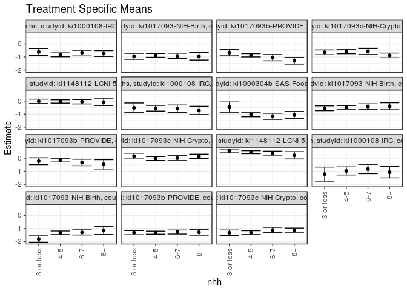

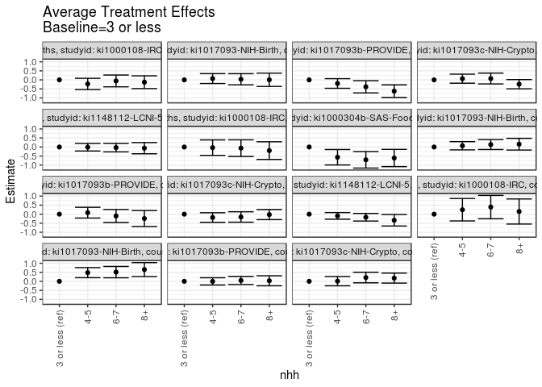

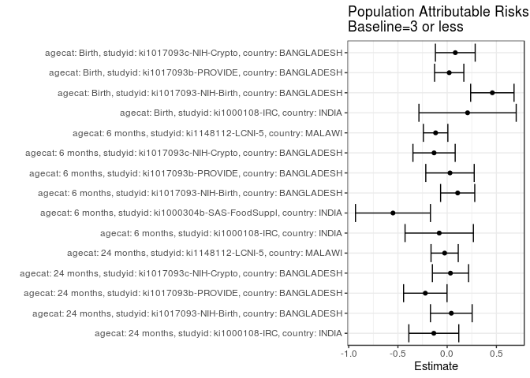

## Results Table

### Parameter: TSM

| agecat | studyid | country | intervention_level | baseline_level | estimate | ci_lower | ci_upper |
| --- | --- | --- | --- | --- | --- | --- | --- |
| Birth | ki1000108-IRC | INDIA | 3 or less | NA | -1.2177278 | -1.7569077 | -0.6785479 |
| Birth | ki1000108-IRC | INDIA | 4-5 | NA | -0.9724118 | -1.2823594 | -0.6624642 |
| Birth | ki1000108-IRC | INDIA | 6-7 | NA | -0.8250725 | -1.1792601 | -0.4708849 |
| Birth | ki1000108-IRC | INDIA | 8+ | NA | -1.0702858 | -1.5048974 | -0.6356741 |
| Birth | ki1017093-NIH-Birth | BANGLADESH | 3 or less | NA | -1.8086310 | -2.0509798 | -1.5662823 |
| Birth | ki1017093-NIH-Birth | BANGLADESH | 4-5 | NA | -1.3282919 | -1.4669421 | -1.1896416 |
| Birth | ki1017093-NIH-Birth | BANGLADESH | 6-7 | NA | -1.2991307 | -1.4982604 | -1.1000010 |
| Birth | ki1017093-NIH-Birth | BANGLADESH | 8+ | NA | -1.1581445 | -1.4597276 | -0.8565613 |
| Birth | ki1017093b-PROVIDE | BANGLADESH | 3 or less | NA | -1.3191813 | -1.4803226 | -1.1580400 |
| Birth | ki1017093b-PROVIDE | BANGLADESH | 4-5 | NA | -1.3219203 | -1.4397581 | -1.2040825 |
| Birth | ki1017093b-PROVIDE | BANGLADESH | 6-7 | NA | -1.2715126 | -1.4266060 | -1.1164191 |
| Birth | ki1017093b-PROVIDE | BANGLADESH | 8+ | NA | -1.2888184 | -1.5166529 | -1.0609839 |
| Birth | ki1017093c-NIH-Crypto | BANGLADESH | 3 or less | NA | -1.3267515 | -1.5367517 | -1.1167512 |
| Birth | ki1017093c-NIH-Crypto | BANGLADESH | 4-5 | NA | -1.3174493 | -1.4657500 | -1.1691486 |
| Birth | ki1017093c-NIH-Crypto | BANGLADESH | 6-7 | NA | -1.1172602 | -1.3221679 | -0.9123526 |
| Birth | ki1017093c-NIH-Crypto | BANGLADESH | 8+ | NA | -1.1486223 | -1.3295769 | -0.9676677 |
| 6 months | ki1000108-IRC | INDIA | 3 or less | NA | -0.5183597 | -0.8881744 | -0.1485450 |
| 6 months | ki1000108-IRC | INDIA | 4-5 | NA | -0.5531398 | -0.7673257 | -0.3389540 |
| 6 months | ki1000108-IRC | INDIA | 6-7 | NA | -0.5813424 | -0.8568137 | -0.3058711 |
| 6 months | ki1000108-IRC | INDIA | 8+ | NA | -0.7164103 | -1.0304071 | -0.4024136 |
| 6 months | ki1000304b-SAS-FoodSuppl | INDIA | 3 or less | NA | -0.4617637 | -0.8508791 | -0.0726483 |
| 6 months | ki1000304b-SAS-FoodSuppl | INDIA | 4-5 | NA | -1.0277073 | -1.2032793 | -0.8521352 |
| 6 months | ki1000304b-SAS-FoodSuppl | INDIA | 6-7 | NA | -1.1690139 | -1.4064033 | -0.9316244 |
| 6 months | ki1000304b-SAS-FoodSuppl | INDIA | 8+ | NA | -1.0701918 | -1.3469349 | -0.7934487 |
| 6 months | ki1017093-NIH-Birth | BANGLADESH | 3 or less | NA | -0.5540966 | -0.7384830 | -0.3697101 |
| 6 months | ki1017093-NIH-Birth | BANGLADESH | 4-5 | NA | -0.4841245 | -0.6208647 | -0.3473842 |
| 6 months | ki1017093-NIH-Birth | BANGLADESH | 6-7 | NA | -0.4184020 | -0.6241086 | -0.2126954 |
| 6 months | ki1017093-NIH-Birth | BANGLADESH | 8+ | NA | -0.3977583 | -0.6640425 | -0.1314742 |
| 6 months | ki1017093b-PROVIDE | BANGLADESH | 3 or less | NA | -0.2278888 | -0.4884398 | 0.0326622 |
| 6 months | ki1017093b-PROVIDE | BANGLADESH | 4-5 | NA | -0.1450042 | -0.2878880 | -0.0021204 |
| 6 months | ki1017093b-PROVIDE | BANGLADESH | 6-7 | NA | -0.3280105 | -0.5754171 | -0.0806040 |
| 6 months | ki1017093b-PROVIDE | BANGLADESH | 8+ | NA | -0.4686050 | -0.8238010 | -0.1134091 |
| 6 months | ki1017093c-NIH-Crypto | BANGLADESH | 3 or less | NA | 0.1628099 | -0.0573152 | 0.3829350 |
| 6 months | ki1017093c-NIH-Crypto | BANGLADESH | 4-5 | NA | -0.0222717 | -0.1712042 | 0.1266608 |
| 6 months | ki1017093c-NIH-Crypto | BANGLADESH | 6-7 | NA | 0.0064314 | -0.1802168 | 0.1930796 |
| 6 months | ki1017093c-NIH-Crypto | BANGLADESH | 8+ | NA | 0.1400020 | -0.0332209 | 0.3132248 |
| 6 months | ki1148112-LCNI-5 | MALAWI | 3 or less | NA | 0.5590613 | 0.4135123 | 0.7046104 |
| 6 months | ki1148112-LCNI-5 | MALAWI | 4-5 | NA | 0.4641273 | 0.3527823 | 0.5754724 |
| 6 months | ki1148112-LCNI-5 | MALAWI | 6-7 | NA | 0.3894306 | 0.2371624 | 0.5416987 |
| 6 months | ki1148112-LCNI-5 | MALAWI | 8+ | NA | 0.2208312 | -0.0608914 | 0.5025538 |
| 24 months | ki1000108-IRC | INDIA | 3 or less | NA | -0.6102681 | -0.8843296 | -0.3362067 |
| 24 months | ki1000108-IRC | INDIA | 4-5 | NA | -0.8353097 | -0.9869528 | -0.6836667 |
| 24 months | ki1000108-IRC | INDIA | 6-7 | NA | -0.6689076 | -0.8470554 | -0.4907597 |
| 24 months | ki1000108-IRC | INDIA | 8+ | NA | -0.7394646 | -0.9633158 | -0.5156135 |
| 24 months | ki1017093-NIH-Birth | BANGLADESH | 3 or less | NA | -0.9535624 | -1.1841511 | -0.7229736 |
| 24 months | ki1017093-NIH-Birth | BANGLADESH | 4-5 | NA | -0.8813110 | -1.0282274 | -0.7343946 |
| 24 months | ki1017093-NIH-Birth | BANGLADESH | 6-7 | NA | -0.9204581 | -1.1260025 | -0.7149137 |
| 24 months | ki1017093-NIH-Birth | BANGLADESH | 8+ | NA | -0.9498686 | -1.2387243 | -0.6610129 |
| 24 months | ki1017093b-PROVIDE | BANGLADESH | 3 or less | NA | -0.6708842 | -0.9083818 | -0.4333865 |
| 24 months | ki1017093b-PROVIDE | BANGLADESH | 4-5 | NA | -0.8710419 | -0.9975226 | -0.7445613 |
| 24 months | ki1017093b-PROVIDE | BANGLADESH | 6-7 | NA | -1.0556119 | -1.2981603 | -0.8130634 |
| 24 months | ki1017093b-PROVIDE | BANGLADESH | 8+ | NA | -1.2960006 | -1.5521547 | -1.0398465 |
| 24 months | ki1017093c-NIH-Crypto | BANGLADESH | 3 or less | NA | -0.6439668 | -0.8259271 | -0.4620064 |
| 24 months | ki1017093c-NIH-Crypto | BANGLADESH | 4-5 | NA | -0.5778390 | -0.7510912 | -0.4045868 |
| 24 months | ki1017093c-NIH-Crypto | BANGLADESH | 6-7 | NA | -0.5697460 | -0.8099985 | -0.3294935 |
| 24 months | ki1017093c-NIH-Crypto | BANGLADESH | 8+ | NA | -0.8830682 | -1.0634685 | -0.7026680 |
| 24 months | ki1148112-LCNI-5 | MALAWI | 3 or less | NA | -0.0221210 | -0.1891106 | 0.1448686 |
| 24 months | ki1148112-LCNI-5 | MALAWI | 4-5 | NA | -0.0327561 | -0.1611266 | 0.0956143 |
| 24 months | ki1148112-LCNI-5 | MALAWI | 6-7 | NA | -0.0544159 | -0.2223366 | 0.1135049 |
| 24 months | ki1148112-LCNI-5 | MALAWI | 8+ | NA | -0.0865709 | -0.3487392 | 0.1755974 |

### Parameter: E(Y)

| agecat | studyid | country | intervention_level | baseline_level | estimate | ci_lower | ci_upper |
| --- | --- | --- | --- | --- | --- | --- | --- |
| Birth | ki1000108-IRC | INDIA | NA | NA | -1.0105831 | -1.1973019 | -0.8238643 |
| Birth | ki1017093-NIH-Birth | BANGLADESH | NA | NA | -1.3499217 | -1.4444634 | -1.2553801 |
| Birth | ki1017093b-PROVIDE | BANGLADESH | NA | NA | -1.2984586 | -1.3752758 | -1.2216415 |
| Birth | ki1017093c-NIH-Crypto | BANGLADESH | NA | NA | -1.2441513 | -1.3281130 | -1.1601897 |
| 6 months | ki1000108-IRC | INDIA | NA | NA | -0.5989297 | -0.7344491 | -0.4634104 |
| 6 months | ki1000304b-SAS-FoodSuppl | INDIA | NA | NA | -1.0121579 | -1.1280429 | -0.8962729 |
| 6 months | ki1017093-NIH-Birth | BANGLADESH | NA | NA | -0.4474038 | -0.5378167 | -0.3569909 |
| 6 months | ki1017093b-PROVIDE | BANGLADESH | NA | NA | -0.1990907 | -0.2817968 | -0.1163845 |
| 6 months | ki1017093c-NIH-Crypto | BANGLADESH | NA | NA | 0.0297622 | -0.0491685 | 0.1086930 |
| 6 months | ki1148112-LCNI-5 | MALAWI | NA | NA | 0.4417647 | 0.3702742 | 0.5132552 |
| 24 months | ki1000108-IRC | INDIA | NA | NA | -0.7458150 | -0.8368180 | -0.6548120 |
| 24 months | ki1017093-NIH-Birth | BANGLADESH | NA | NA | -0.9115790 | -1.0095022 | -0.8136559 |
| 24 months | ki1017093b-PROVIDE | BANGLADESH | NA | NA | -0.8928670 | -0.9755153 | -0.8102187 |
| 24 months | ki1017093c-NIH-Crypto | BANGLADESH | NA | NA | -0.6103502 | -0.7050157 | -0.5156847 |
| 24 months | ki1148112-LCNI-5 | MALAWI | NA | NA | -0.0477867 | -0.1301103 | 0.0345368 |

### Parameter: ATE

| agecat | studyid | country | intervention_level | baseline_level | estimate | ci_lower | ci_upper |
| --- | --- | --- | --- | --- | --- | --- | --- |
| Birth | ki1000108-IRC | INDIA | 3 or less | 3 or less | 0.0000000 | 0.0000000 | 0.0000000 |
| Birth | ki1000108-IRC | INDIA | 4-5 | 3 or less | 0.2453160 | -0.3755617 | 0.8661937 |
| Birth | ki1000108-IRC | INDIA | 6-7 | 3 or less | 0.3926553 | -0.2540744 | 1.0393850 |
| Birth | ki1000108-IRC | INDIA | 8+ | 3 or less | 0.1474420 | -0.5474083 | 0.8422924 |
| Birth | ki1017093-NIH-Birth | BANGLADESH | 3 or less | 3 or less | 0.0000000 | 0.0000000 | 0.0000000 |
| Birth | ki1017093-NIH-Birth | BANGLADESH | 4-5 | 3 or less | 0.4803392 | 0.2009659 | 0.7597124 |
| Birth | ki1017093-NIH-Birth | BANGLADESH | 6-7 | 3 or less | 0.5095003 | 0.1951304 | 0.8238702 |
| Birth | ki1017093-NIH-Birth | BANGLADESH | 8+ | 3 or less | 0.6504866 | 0.2633809 | 1.0375923 |
| Birth | ki1017093b-PROVIDE | BANGLADESH | 3 or less | 3 or less | 0.0000000 | 0.0000000 | 0.0000000 |
| Birth | ki1017093b-PROVIDE | BANGLADESH | 4-5 | 3 or less | -0.0027390 | -0.2024022 | 0.1969241 |
| Birth | ki1017093b-PROVIDE | BANGLADESH | 6-7 | 3 or less | 0.0476687 | -0.1753607 | 0.2706981 |
| Birth | ki1017093b-PROVIDE | BANGLADESH | 8+ | 3 or less | 0.0303628 | -0.2478946 | 0.3086202 |
| Birth | ki1017093c-NIH-Crypto | BANGLADESH | 3 or less | 3 or less | 0.0000000 | 0.0000000 | 0.0000000 |
| Birth | ki1017093c-NIH-Crypto | BANGLADESH | 4-5 | 3 or less | 0.0093021 | -0.2478373 | 0.2664416 |
| Birth | ki1017093c-NIH-Crypto | BANGLADESH | 6-7 | 3 or less | 0.2094912 | -0.0839148 | 0.5028972 |
| Birth | ki1017093c-NIH-Crypto | BANGLADESH | 8+ | 3 or less | 0.1781292 | -0.0982769 | 0.4545353 |
| 6 months | ki1000108-IRC | INDIA | 3 or less | 3 or less | 0.0000000 | 0.0000000 | 0.0000000 |
| 6 months | ki1000108-IRC | INDIA | 4-5 | 3 or less | -0.0347801 | -0.4625423 | 0.3929820 |
| 6 months | ki1000108-IRC | INDIA | 6-7 | 3 or less | -0.0629827 | -0.5230054 | 0.3970400 |
| 6 months | ki1000108-IRC | INDIA | 8+ | 3 or less | -0.1980506 | -0.6867095 | 0.2906083 |
| 6 months | ki1000304b-SAS-FoodSuppl | INDIA | 3 or less | 3 or less | 0.0000000 | 0.0000000 | 0.0000000 |
| 6 months | ki1000304b-SAS-FoodSuppl | INDIA | 4-5 | 3 or less | -0.5659436 | -0.9930484 | -0.1388388 |
| 6 months | ki1000304b-SAS-FoodSuppl | INDIA | 6-7 | 3 or less | -0.7072502 | -1.1640053 | -0.2504951 |
| 6 months | ki1000304b-SAS-FoodSuppl | INDIA | 8+ | 3 or less | -0.6084281 | -1.0856798 | -0.1311765 |
| 6 months | ki1017093-NIH-Birth | BANGLADESH | 3 or less | 3 or less | 0.0000000 | 0.0000000 | 0.0000000 |
| 6 months | ki1017093-NIH-Birth | BANGLADESH | 4-5 | 3 or less | 0.0699721 | -0.1585181 | 0.2984622 |
| 6 months | ki1017093-NIH-Birth | BANGLADESH | 6-7 | 3 or less | 0.1356946 | -0.1392491 | 0.4106383 |
| 6 months | ki1017093-NIH-Birth | BANGLADESH | 8+ | 3 or less | 0.1563382 | -0.1667284 | 0.4794048 |
| 6 months | ki1017093b-PROVIDE | BANGLADESH | 3 or less | 3 or less | 0.0000000 | 0.0000000 | 0.0000000 |
| 6 months | ki1017093b-PROVIDE | BANGLADESH | 4-5 | 3 or less | 0.0828846 | -0.2140450 | 0.3798143 |
| 6 months | ki1017093b-PROVIDE | BANGLADESH | 6-7 | 3 or less | -0.1001217 | -0.4594841 | 0.2592407 |
| 6 months | ki1017093b-PROVIDE | BANGLADESH | 8+ | 3 or less | -0.2407162 | -0.6807407 | 0.1993083 |
| 6 months | ki1017093c-NIH-Crypto | BANGLADESH | 3 or less | 3 or less | 0.0000000 | 0.0000000 | 0.0000000 |
| 6 months | ki1017093c-NIH-Crypto | BANGLADESH | 4-5 | 3 or less | -0.1850816 | -0.4508910 | 0.0807278 |
| 6 months | ki1017093c-NIH-Crypto | BANGLADESH | 6-7 | 3 or less | -0.1563785 | -0.4449861 | 0.1322291 |
| 6 months | ki1017093c-NIH-Crypto | BANGLADESH | 8+ | 3 or less | -0.0228079 | -0.3029660 | 0.2573502 |
| 6 months | ki1148112-LCNI-5 | MALAWI | 3 or less | 3 or less | 0.0000000 | 0.0000000 | 0.0000000 |
| 6 months | ki1148112-LCNI-5 | MALAWI | 4-5 | 3 or less | -0.0949340 | -0.2783380 | 0.0884700 |
| 6 months | ki1148112-LCNI-5 | MALAWI | 6-7 | 3 or less | -0.1696307 | -0.3804081 | 0.0411466 |
| 6 months | ki1148112-LCNI-5 | MALAWI | 8+ | 3 or less | -0.3382301 | -0.6553402 | -0.0211201 |
| 24 months | ki1000108-IRC | INDIA | 3 or less | 3 or less | 0.0000000 | 0.0000000 | 0.0000000 |
| 24 months | ki1000108-IRC | INDIA | 4-5 | 3 or less | -0.2250416 | -0.5383651 | 0.0882819 |
| 24 months | ki1000108-IRC | INDIA | 6-7 | 3 or less | -0.0586394 | -0.3851395 | 0.2678606 |
| 24 months | ki1000108-IRC | INDIA | 8+ | 3 or less | -0.1291965 | -0.4837824 | 0.2253894 |
| 24 months | ki1017093-NIH-Birth | BANGLADESH | 3 or less | 3 or less | 0.0000000 | 0.0000000 | 0.0000000 |
| 24 months | ki1017093-NIH-Birth | BANGLADESH | 4-5 | 3 or less | 0.0722514 | -0.2005155 | 0.3450184 |
| 24 months | ki1017093-NIH-Birth | BANGLADESH | 6-7 | 3 or less | 0.0331043 | -0.2755885 | 0.3417970 |
| 24 months | ki1017093-NIH-Birth | BANGLADESH | 8+ | 3 or less | 0.0036938 | -0.3655695 | 0.3729570 |
| 24 months | ki1017093b-PROVIDE | BANGLADESH | 3 or less | 3 or less | 0.0000000 | 0.0000000 | 0.0000000 |
| 24 months | ki1017093b-PROVIDE | BANGLADESH | 4-5 | 3 or less | -0.2001578 | -0.4662283 | 0.0659127 |
| 24 months | ki1017093b-PROVIDE | BANGLADESH | 6-7 | 3 or less | -0.3847277 | -0.7221182 | -0.0473372 |
| 24 months | ki1017093b-PROVIDE | BANGLADESH | 8+ | 3 or less | -0.6251164 | -0.9735273 | -0.2767056 |
| 24 months | ki1017093c-NIH-Crypto | BANGLADESH | 3 or less | 3 or less | 0.0000000 | 0.0000000 | 0.0000000 |
| 24 months | ki1017093c-NIH-Crypto | BANGLADESH | 4-5 | 3 or less | 0.0661278 | -0.1844424 | 0.3166979 |
| 24 months | ki1017093c-NIH-Crypto | BANGLADESH | 6-7 | 3 or less | 0.0742207 | -0.2259922 | 0.3744337 |
| 24 months | ki1017093c-NIH-Crypto | BANGLADESH | 8+ | 3 or less | -0.2391015 | -0.4950579 | 0.0168550 |
| 24 months | ki1148112-LCNI-5 | MALAWI | 3 or less | 3 or less | 0.0000000 | 0.0000000 | 0.0000000 |
| 24 months | ki1148112-LCNI-5 | MALAWI | 4-5 | 3 or less | -0.0106351 | -0.2218437 | 0.2005734 |
| 24 months | ki1148112-LCNI-5 | MALAWI | 6-7 | 3 or less | -0.0322949 | -0.2691304 | 0.2045407 |
| 24 months | ki1148112-LCNI-5 | MALAWI | 8+ | 3 or less | -0.0644499 | -0.3743525 | 0.2454527 |

### Parameter: PAR

| agecat | studyid | country | intervention_level | baseline_level | estimate | ci_lower | ci_upper |
| --- | --- | --- | --- | --- | --- | --- | --- |
| Birth | ki1000108-IRC | INDIA | 3 or less | NA | 0.2071447 | -0.2866768 | 0.7009662 |
| Birth | ki1017093-NIH-Birth | BANGLADESH | 3 or less | NA | 0.4587093 | 0.2384157 | 0.6790029 |
| Birth | ki1017093b-PROVIDE | BANGLADESH | 3 or less | NA | 0.0207226 | -0.1278003 | 0.1692455 |
| Birth | ki1017093c-NIH-Crypto | BANGLADESH | 3 or less | NA | 0.0826001 | -0.1192960 | 0.2844962 |
| 6 months | ki1000108-IRC | INDIA | 3 or less | NA | -0.0805700 | -0.4275701 | 0.2664301 |
| 6 months | ki1000304b-SAS-FoodSuppl | INDIA | 3 or less | NA | -0.5503942 | -0.9309737 | -0.1698148 |
| 6 months | ki1017093-NIH-Birth | BANGLADESH | 3 or less | NA | 0.1066928 | -0.0668060 | 0.2801916 |
| 6 months | ki1017093b-PROVIDE | BANGLADESH | 3 or less | NA | 0.0287982 | -0.2170248 | 0.2746212 |
| 6 months | ki1017093c-NIH-Crypto | BANGLADESH | 3 or less | NA | -0.1330476 | -0.3474753 | 0.0813800 |
| 6 months | ki1148112-LCNI-5 | MALAWI | 3 or less | NA | -0.1172966 | -0.2415504 | 0.0069571 |
| 24 months | ki1000108-IRC | INDIA | 3 or less | NA | -0.1355469 | -0.3890298 | 0.1179361 |
| 24 months | ki1017093-NIH-Birth | BANGLADESH | 3 or less | NA | 0.0419833 | -0.1696253 | 0.2535919 |
| 24 months | ki1017093b-PROVIDE | BANGLADESH | 3 or less | NA | -0.2219829 | -0.4425673 | -0.0013984 |
| 24 months | ki1017093c-NIH-Crypto | BANGLADESH | 3 or less | NA | 0.0336166 | -0.1500784 | 0.2173116 |
| 24 months | ki1148112-LCNI-5 | MALAWI | 3 or less | NA | -0.0256657 | -0.1637944 | 0.1124629 |